# Module 2. Preparing and exploring longitudinal data in R

Practical assessment

```r
source(here::here("R", "setup.R"))
walk <- load_walk()
```

**WarningSimulated data**

All examples use simulated data from fictional studies. Results illustrate methods; they are not empirical findings.

**NoteFor instructors**

## 1 Task brief

You are the data analyst for the WALK trial. The trial database has produced a new visit-level export, `pa02_walk_visits.csv`. Your task is to turn it into a checked analysis file, describe the data, and explain to the trial team what the exploratory analysis implies for the main analysis. Work in a single Quarto document or R script that runs from top to bottom from the course project root.

The export has 1911 rows and five columns, all to be treated as text:

| Column | Content |
| --- | --- |
| `subject` | Participant identifier; the protocol format is `W` followed by three digits |
| `visit` | Visit label |
| `date` | Visit date |
| `sbp` | Systolic blood pressure, mmHg |
| `steps` | Average daily steps, thousands per day |

The participant-level file is `data/walk_baseline.csv` (randomisation date, arm and baseline covariates for the 360 randomised participants). Scheduled visits are at months 0, 1, 3, 6, 9 and 12, and a month is 30.44 days. The protocol windows are ±7 days (month 1), ±14 days (month 3) and ±28 days (months 6, 9 and 12). The data management plan states:

- SBP outside 70–250 mmHg is implausible: set it to missing, keep the raw value and log a query.
- When two different records exist for the same participant and visit, keep the earliest-dated record and flag the visit.
- Records that cannot be linked to a randomised participant are excluded from the analysis file and queried.
- Visits outside the window are kept and flagged.

You may use `walk_long.csv` **only** for a final agreement check (deliverable 3). Do not use it, or `walk_complete.csv`, at any other stage.

## 2 Data

```r
pa_preview <- read_csv(here("assessments", "pa02-data", "pa02_walk_visits.csv"),
                       col_types = cols(.default = col_character()))
head(pa_preview, 8)
```

```
#> # A tibble: 8 × 5
#>   subject visit date       sbp      steps
#>   <chr>   <chr> <chr>      <chr>    <chr>
#> 1 W315    M1    2024-08-12 149      3.7
#> 2 W123    M9    2025-04-02 147      8.8
#> 3 W070    M9    2025-05-03 130      3.8
#> 4 W160    M3    2024-04-18 126      13.7
#> 5 W206    M1    2024-07-20 139      9.3
#> 6 W292    M9    2025-01-13 174 mmHg 5.9
#> 7 W272    M3    2025-02-11 149      6.7
#> 8 W054    M12   2025-03-04 121      8.7
```

## 3 Deliverables

1. **Cleaning code and cleaned file.** Code that reads the export as text and produces an analysis file with one row per participant and visit, containing `id`, `visit` (1–6), `month_sched`, `visit_date`, actual time `month`, `sbp`, `steps`, and flags for conflicting duplicates, SBP problems, date problems and out-of-window visits. Use `stopifnot()` or equivalent checks after each major step.
2. **Cleaning log and query log.** A table with the number of records affected at each step, and a table with one row per queried record (participant, visit, issue, raw value, action).
3. **Validation.** A check of the cleaned file against `walk_baseline.csv` (unmatched keys in both directions, `relationship =`), and an agreement check against `walk_long.csv`, with every difference explained.
4. **Description.** A baseline table by arm; SBP by arm and scheduled visit (n, mean, SD); a participant-flow table with n (% of randomised); counts of intermittent missing visits and visits missing after dropout by arm, based on a grid built from the design.
5. **Plots.** A spaghetti plot of a random subset of participants, observed mean SBP by arm and visit, a missingness map, and a plot or table that shows whether participants who drop out differ from those who stay.
6. **Short report (at most 600 words).** Summarise the cleaning decisions, describe the data, and explain to the trial team why the observed mean SBP at each visit should not be presented as the estimated trajectory in each arm.

## 4 Marking guide

Total 100 marks. A pass requires 50 marks, including at least 10 of the 15 marks for criterion C.

[output not shown]

**Common deductions.** Duplicates sought before IDs are standardised (−4 from C). Out-of-window visits deleted (−4 from D). Implausible value “corrected” without a documented rule (−3 from D). The non-randomised participant left in the analysis file (−4 from E). Grid built from the observed data (−3 from G). Hand-picked subset in the spaghetti plot (−2 from H). Report describes observed means as the treatment effect (−5 from I).

## 5 Model solution (for instructors)

The solution below is executed when this document is rendered, so its numbers are the reference values for marking.

### 5.1 Reading and standardising

```r
raw <- read_csv(here("assessments", "pa02-data", "pa02_walk_visits.csv"),
                col_types = cols(.default = col_character()))

parse_label <- function(x) {
  x <- tolower(trimws(x))
  x <- ifelse(x == "baseline", "0", gsub("month|m|\\s", "", x))
  as.numeric(x)
}
step1 <- raw |>
  mutate(id          = toupper(gsub("[[:space:]-]", "", subject)),
         month_sched = parse_label(visit),
         visit       = match(month_sched, sched_months),
         visit_date  = coalesce(as.Date(date, format = "%Y-%m-%d"),
                                as.Date(date, format = "%d/%m/%Y")),
         sbp_num     = parse_number(sbp, na = c("", "NA", "missing")),
         steps_num   = parse_double(sub(",", ".", steps, fixed = TRUE)))
stopifnot(all(grepl("^W[0-9]{3}$", step1$id)), !anyNA(step1$visit),
          !anyNA(step1$visit_date), !anyNA(step1$steps_num))

format_counts <- c(
  ids_changed      = sum(step1$id != raw$subject),
  labels_not_Mx    = sum(!grepl("^M[0-9]+$", raw$visit)),
  dates_dd_mm_yyyy = sum(grepl("/", raw$date)),
  sbp_with_unit    = sum(grepl("mmHg", raw$sbp)),
  sbp_text_code    = sum(raw$sbp == "missing", na.rm = TRUE),
  steps_comma      = sum(grepl(",", raw$steps)))
format_counts
```

```
#>      ids_changed    labels_not_Mx dates_dd_mm_yyyy    sbp_with_unit
#>               33               61               42               15
#>    sbp_text_code      steps_comma
#>                1               10
```

### 5.2 Duplicates

```r
step2 <- step1 |> select(id, visit, month_sched, visit_date,
                         sbp = sbp_num, steps = steps_num)
n_exact <- sum(duplicated(step2))
n_exact_naive <- sum(duplicated(raw))
step3 <- distinct(step2)

conflicts <- step3 |> add_count(id, visit, name = "n_records") |>
  filter(n_records > 1) |> arrange(id, visit, visit_date)
conflicts
```

```
#> # A tibble: 8 × 7
#>   id    visit month_sched visit_date   sbp steps n_records
#>   <chr> <int>       <dbl> <date>     <dbl> <dbl>     <int>
#> 1 W023      1           0 2024-04-15   148   6.5         2
#> 2 W023      1           0 2024-04-16   140   6.5         2
#> 3 W119      3           3 2024-05-29   102   9.2         2
#> 4 W119      3           3 2024-06-01   107   9.2         2
#> 5 W245      6          12 2025-04-02   121   9.4         2
#> 6 W245      6          12 2025-04-04   133   9.4         2
#> 7 W275      6          12 2025-04-03   141   7.9         2
#> 8 W275      6          12 2025-04-04   137   7.9         2
```

```r
step4 <- step3 |>
  group_by(id, visit) |>
  mutate(conflict_flag = n() > 1) |>
  arrange(visit_date, .by_group = TRUE) |>
  slice(1) |> ungroup()
stopifnot(nrow(count(step4, id, visit) |> filter(n > 1)) == 0)
c(exact_after_standardising = n_exact, exact_in_raw_text = n_exact_naive,
  conflicting_visits = n_distinct(paste(conflicts$id, conflicts$visit)))
```

```
#> exact_after_standardising         exact_in_raw_text        conflicting_visits
#>                         8                         3                         4
```

Only 3 of the 8 exact duplicates are identical in the raw text. The other 5 differ from their original only in formatting (ID case or spacing, label or date format) and are found only after standardisation. A participant who removes duplicates before standardising will find 3 and may then misreport the rest as conflicting duplicates.

### 5.3 Linkage, time, plausibility and windows

```r
orphans <- anti_join(step4, baseline, by = "id")
orphans
```

```
#> # A tibble: 2 × 7
#>   id    visit month_sched visit_date   sbp steps conflict_flag
#>   <chr> <int>       <dbl> <date>     <dbl> <dbl> <lgl>
#> 1 W377      1           0 2024-04-21   174   4.4 FALSE
#> 2 W377      2           1 2024-05-20   160   5.3 FALSE
```

```r
never_seen <- anti_join(baseline, step4, by = "id")
nrow(never_seen)
```

```
#> [1] 0
```

```r
window_days <- c(`0` = 0, `1` = 7, `3` = 14, `6` = 28, `9` = 28, `12` = 28)
clean <- step4 |>
  semi_join(baseline, by = "id") |>
  left_join(baseline |> select(id, arm, rand_date), by = "id",
            relationship = "many-to-one", unmatched = "error") |>
  mutate(days = as.numeric(visit_date - rand_date),
         date_flag = if_else(days < 0, "before randomisation", "ok"),
         visit_date = if_else(date_flag == "ok", visit_date, as.Date(NA)),
         month = round(as.numeric(visit_date - rand_date) / 30.44, 2),
         dev_days = as.numeric(visit_date - (rand_date + round(month_sched * 30.44))),
         out_of_window = abs(dev_days) > window_days[as.character(month_sched)],
         sbp_flag = case_when(is.na(sbp) ~ "missing",
                              sbp < 70 | sbp > 250 ~ "implausible",
                              TRUE ~ "ok"),
         sbp_raw = sbp,
         sbp = if_else(sbp_flag == "implausible", NA_real_, sbp)) |>
  select(id, arm, visit, month_sched, visit_date, month, dev_days,
         out_of_window, sbp, sbp_raw, sbp_flag, steps, conflict_flag,
         date_flag) |>
  arrange(id, visit)
clean |> filter(sbp_flag != "ok" | date_flag != "ok") |>
  select(id, visit, month_sched, sbp_raw, sbp_flag, date_flag)
```

```
#> # A tibble: 3 × 6
#>   id    visit month_sched sbp_raw sbp_flag    date_flag
#>   <chr> <int>       <dbl>   <dbl> <chr>       <chr>
#> 1 W018      3           3     133 ok          before randomisation
#> 2 W085      6          12    1160 implausible ok
#> 3 W276      2           1      NA missing     ok
```

The visit dated before randomisation has an impossible date, most likely a wrong year. Its date and actual time are set to missing and a query is raised. Its SBP is kept, because the visit took place, but a model that uses actual time cannot use it until the date is resolved.

```r
clean |> filter(visit > 1, !is.na(dev_days)) |>
  group_by(month_sched) |>
  summarise(window = first(window_days[as.character(month_sched)]), n = n(),
            sd_dev = round(sd(dev_days), 1), n_out = sum(out_of_window))
```

```
#> # A tibble: 5 × 5
#>   month_sched window     n sd_dev n_out
#>         <dbl>  <dbl> <int>  <dbl> <int>
#> 1           1      7   324    3.7    10
#> 2           3     14   318    7.6    15
#> 3           6     28   309   10.2     0
#> 4           9     28   297   12.4     3
#> 5          12     28   288   13.6     6
```

### 5.4 Logs

```r
cleaning_log <- tibble(
  step = c("Records read", "Exact duplicates removed (after standardising)",
           "Visits with conflicting records (earliest kept)",
           "Records from non-randomised IDs excluded",
           "Records in analysis file", "SBP missing (text code)",
           "Implausible SBP set to missing", "Dates before randomisation",
           "Out-of-window visits (kept, flagged)"),
  n = c(nrow(raw), n_exact, n_distinct(paste(conflicts$id, conflicts$visit)),
        nrow(orphans), nrow(clean), sum(clean$sbp_flag == "missing"),
        sum(clean$sbp_flag == "implausible"),
        sum(clean$date_flag != "ok"), sum(clean$out_of_window, na.rm = TRUE)))
knitr::kable(cleaning_log)
```

| step | n |
| --- | --- |
| Records read | 1911 |
| Exact duplicates removed (after standardising) | 8 |
| Visits with conflicting records (earliest kept) | 4 |
| Records from non-randomised IDs excluded | 2 |
| Records in analysis file | 1897 |
| SBP missing (text code) | 1 |
| Implausible SBP set to missing | 1 |
| Dates before randomisation | 1 |
| Out-of-window visits (kept, flagged) | 34 |

```r
stopifnot(nrow(raw) - n_exact - n_distinct(paste(conflicts$id, conflicts$visit)) -
            nrow(orphans) == nrow(clean))

query_log <- bind_rows(
  conflicts |> transmute(id, visit, issue = "conflicting duplicate",
                         raw_value = paste0(visit_date, ", SBP ", sbp),
                         action = "earliest-dated record kept"),
  orphans |> transmute(id, visit, issue = "ID not randomised",
                       raw_value = as.character(sbp), action = "excluded"),
  clean |> filter(sbp_flag != "ok") |>
    transmute(id, visit, issue = paste("SBP", sbp_flag),
              raw_value = as.character(sbp_raw), action = "set to missing"),
  clean |> filter(date_flag != "ok") |>
    transmute(id, visit, issue = "date before randomisation",
              raw_value = raw$date[match(paste(id, visit),
                                         paste(step1$id, step1$visit))],
              action = "date and month set to missing"))
knitr::kable(query_log)
```

| id | visit | issue | raw_value | action |
| --- | --- | --- | --- | --- |
| W023 | 1 | conflicting duplicate | 2024-04-15, SBP 148 | earliest-dated record kept |
| W023 | 1 | conflicting duplicate | 2024-04-16, SBP 140 | earliest-dated record kept |
| W119 | 3 | conflicting duplicate | 2024-05-29, SBP 102 | earliest-dated record kept |
| W119 | 3 | conflicting duplicate | 2024-06-01, SBP 107 | earliest-dated record kept |
| W245 | 6 | conflicting duplicate | 2025-04-02, SBP 121 | earliest-dated record kept |
| W245 | 6 | conflicting duplicate | 2025-04-04, SBP 133 | earliest-dated record kept |
| W275 | 6 | conflicting duplicate | 2025-04-03, SBP 141 | earliest-dated record kept |
| W275 | 6 | conflicting duplicate | 2025-04-04, SBP 137 | earliest-dated record kept |
| W377 | 1 | ID not randomised | 174 | excluded |
| W377 | 2 | ID not randomised | 160 | excluded |
| W085 | 6 | SBP implausible | 1160 | set to missing |
| W276 | 2 | SBP missing | NA | set to missing |
| W018 | 3 | date before randomisation | 2023-12-25 | date and month set to missing |

The row counts reconcile: records read minus exact duplicates, minus the extra record of each conflicting pair, minus the non-randomised records equals the number of rows in the analysis file.

### 5.5 Agreement with `walk_long.csv`

```r
agree <- clean |>
  full_join(walk |> select(id, visit, month_ref = month, sbp_ref = sbp,
                           steps_ref = steps), by = c("id", "visit"))
c(only_clean = sum(is.na(agree$steps_ref)),
  only_walk_long = sum(is.na(agree$steps)),
  steps_differ = sum(agree$steps != agree$steps_ref, na.rm = TRUE))
```

```
#>     only_clean only_walk_long   steps_differ
#>              0              0              0
```

```r
agree |> filter(is.na(sbp) | sbp != sbp_ref) |> select(id, visit, sbp, sbp_raw, sbp_ref)
```

```
#> # A tibble: 2 × 5
#>   id    visit   sbp sbp_raw sbp_ref
#>   <chr> <dbl> <dbl>   <dbl>   <dbl>
#> 1 W085      6    NA    1160     116
#> 2 W276      2    NA      NA     157
```

```r
table(round(agree$month - agree$month_ref, 2), useNA = "ifany")
```

```
#>
#> -0.02 -0.01     0  0.01  0.02  <NA>
#>    72   471   829   453    71     1
```

The keys agree exactly, steps agree everywhere, and SBP differs only where the cleaning set a value to missing (the text code and the ×10 typo). Month differs by at most 0.02 months because the export’s dates are whole days, and is missing for the visit with the impossible date.

### 5.6 Description

```r
mean_sd <- function(x) sprintf("%.1f (%.1f)", mean(x, na.rm = TRUE), sd(x, na.rm = TRUE))
baseline |>
  group_by(arm) |>
  summarise(n = as.character(n()), Age = mean_sd(age),
            `Female, n (%)` = sprintf("%d (%.0f%%)", sum(sex == "Female"),
                                      100 * mean(sex == "Female")),
            BMI = mean_sd(bmi), `Baseline SBP` = mean_sd(sbp0)) |>
  pivot_longer(-arm, names_to = "Characteristic") |>
  pivot_wider(names_from = arm, values_from = value) |>
  knitr::kable()
```

| Characteristic | UC | SP | EP |
| --- | --- | --- | --- |
| n | 120 | 120 | 120 |
| Age | 59.6 (9.4) | 60.1 (8.3) | 60.5 (9.2) |
| Female, n (%) | 65 (54%) | 68 (57%) | 57 (48%) |
| BMI | 28.6 (4.0) | 30.0 (4.2) | 29.3 (4.4) |
| Baseline SBP | 146.2 (12.6) | 147.2 (14.1) | 147.5 (13.2) |

```r
clean |> group_by(arm, month_sched) |>
  summarise(n = sum(!is.na(sbp)), mean = round(mean(sbp, na.rm = TRUE), 1),
            sd = round(sd(sbp, na.rm = TRUE), 1)) |>
  print(n = 18)
```

```
#> # A tibble: 18 × 5
#> # Groups:   arm [3]
#>    arm   month_sched     n  mean    sd
#>    <fct>       <dbl> <int> <dbl> <dbl>
#>  1 UC              0   120 146.2  12.6
#>  2 UC              1   107 143.4  11.7
#>  3 UC              3   106 142.7  12.2
#>  4 UC              6   101 142.9  12.4
#>  5 UC              9    99 143.6  12.6
#>  6 UC             12    95 144.3  13.3
#>  7 SP              0   120 147.2  14.1
#>  8 SP              1   106 144    14.4
#>  9 SP              3   110 141.4  14.1
#> 10 SP              6   103 140    14
#> 11 SP              9   102 139    13.8
#> 12 SP             12   100 139.6  13.1
#> 13 EP              0   120 147.5  13.2
#> 14 EP              1   110 142.6  13.6
#> 15 EP              3   103 139    12.9
#> 16 EP              6   105 136.1  13.1
#> 17 EP              9    96 136.8  13.3
#> 18 EP             12    92 136.8  12.5
```

```r
visit_flow(clean, id, month_sched, arm) |>
  left_join(count(baseline, arm, name = "randomised"), by = "arm") |>
  mutate(cell = sprintf("%d (%.0f%%)", n_seen, 100 * n_seen / randomised)) |>
  select(arm, month_sched, cell) |>
  pivot_wider(names_from = arm, values_from = cell) |>
  knitr::kable()
```

| month_sched | UC | SP | EP |
| --- | --- | --- | --- |
| 0 | 120 (100%) | 120 (100%) | 120 (100%) |
| 1 | 107 (89%) | 107 (89%) | 110 (92%) |
| 3 | 106 (88%) | 110 (92%) | 103 (86%) |
| 6 | 101 (84%) | 103 (86%) | 105 (88%) |
| 9 | 99 (82%) | 102 (85%) | 96 (80%) |
| 12 | 95 (79%) | 100 (83%) | 93 (78%) |

```r
grid <- baseline |> select(id, arm) |>
  crossing(visit = 1:6) |>
  mutate(month_sched = sched_months[visit]) |>
  left_join(clean |> select(id, visit) |> mutate(attended = TRUE),
            by = c("id", "visit")) |>
  mutate(observed = !is.na(attended)) |>
  group_by(id) |>
  mutate(last_seen = max(visit[observed]),
         miss_type = case_when(observed ~ "attended",
                               visit < last_seen ~ "intermittent",
                               TRUE ~ "after dropout")) |>
  ungroup()
count(grid, arm, miss_type) |> pivot_wider(names_from = miss_type, values_from = n)
```

```
#> # A tibble: 3 × 4
#>   arm   `after dropout` attended intermittent
#>   <fct>           <int>    <int>        <int>
#> 1 UC                 71      628           21
#> 2 SP                 58      642           20
#> 3 EP                 74      627           19
```

### 5.7 Plots

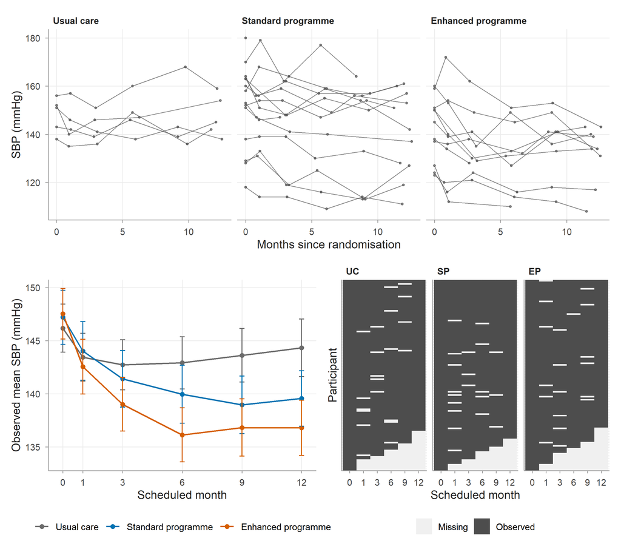

```r
clean_lab <- clean |>
  mutate(arm_lab = factor(walk_arm_labels[as.character(arm)], levels = walk_arm_labels))
p_spag <- plot_spaghetti(clean_lab |> filter(!is.na(sbp), !is.na(month)),
                         month, sbp, id, group = arm_lab, n_show = 30, seed = 11,
                         alpha = 0.7) +
  labs(x = "Months since randomisation", y = "SBP (mmHg)")
p_mean <- plot_observed_means(clean_lab |> filter(!is.na(sbp)), month_sched, sbp,
                              arm_lab) +
  scale_x_continuous(breaks = sched_months) +
  labs(x = "Scheduled month", y = "Observed mean SBP (mmHg)")
p_map <- plot_missing_map(grid, id, visit, observed, order_by = last_seen) +
  facet_wrap(~ arm, scales = "free_y") +
  scale_x_discrete(labels = sched_months) + labs(x = "Scheduled month")
p_spag / (p_mean | p_map)
```

```r
last_info <- grid |> distinct(id, last_seen)
drop_cmp <- clean |>
  filter(!is.na(sbp), visit < 6) |>
  left_join(last_info, by = "id") |>
  group_by(arm, visit) |>
  mutate(dev = sbp - mean(sbp)) |>
  ungroup() |>
  mutate(status = if_else(visit == last_seen, "Last visit before dropout",
                          "Seen again later")) |>
  group_by(status) |>
  summarise(n = n(), mean_dev = round(mean(dev), 2))
drop_cmp
```

```
#> # A tibble: 2 × 3
#>   status                        n mean_dev
#>   <chr>                     <int>    <dbl>
#> 1 Last visit before dropout    72     5.13
#> 2 Seen again later           1536    -0.24
```

### 5.8 Model report (abridged)

The export contained 1911 records. After standardising identifiers, visit labels, date formats and number formats, 8 exact duplicate records were removed (only 3 of them were identical before standardisation). 4 visits had conflicting records; by the prespecified rule the earliest-dated record was kept and the visit flagged. This rule was fixed in the data management plan and applied without reference to arm or outcomes, so that the choice cannot favour either arm. 2 records from an identifier not on the randomisation list were excluded and queried. One SBP value was coded as text (“missing”), one was implausible (1160 mmHg) and one visit was dated before randomisation. All are queried. The analysis file has 1897 visits from 360 participants and agrees with the reference file apart from these documented changes and sub-day rounding of actual time.

Of the 2160 scheduled visits, 263 were not attended, mostly after dropout. Participants who dropped out had SBP on average 5.13 mmHg above their arm’s mean at their last visit. Because participants with higher SBP leave, those still measured at later visits are a selected, lower-SBP group, and the observed visit means drift below the means of all randomised participants. They should be reported descriptively with their numbers of participants. The trajectories and treatment effects should be estimated with a mixed model fitted to all observed data, which is valid if dropout depends only on observed data (MAR). That assumption cannot be checked from the data and will be explored in sensitivity analyses.

### 5.9 Code used to generate the assessment data

```r
# Build a new messy export from the WALK visits with a fixed seed.
# The problems differ from walk_visits_raw.csv used in the notes.
set.seed(20260202)
baseline <- load_walk("baseline")
sched_months <- c(0, 1, 3, 6, 9, 12)

base_rows <- walk |>
  left_join(baseline |> select(id, rand_date), by = "id") |>
  mutate(visit_date = rand_date + round(month * 30.44),
         row_id = row_number())

# rows reserved for single-row problems (never duplicated)
special <- sample(base_rows$row_id[base_rows$visit > 1], 3)
dup_pool <- setdiff(base_rows$row_id, special)
dup_exact <- sample(dup_pool, 8)
dup_conf  <- sample(setdiff(dup_pool, dup_exact), 4)

pa <- bind_rows(
  base_rows |> mutate(copy = "original"),
  base_rows |> filter(row_id %in% dup_exact) |> mutate(copy = "exact"),
  base_rows |> filter(row_id %in% dup_conf) |> mutate(copy = "conflict") |>
    mutate(sbp = sbp + c(-8, 5, 12, -4),
           visit_date = visit_date + c(1, 3, 2, 1))
) |>
  mutate(sbp_txt = as.character(sbp),
         steps_txt = as.character(steps),
         date_txt = format(visit_date, "%Y-%m-%d"),
         label = paste0("M", month_sched))

# single-row problems
pa$sbp_txt[pa$row_id == special[1]][1] <- paste0(pa$sbp[pa$row_id == special[1]][1], "0")  # x10 typo
pa$sbp_txt[pa$row_id == special[2]][1] <- "missing"                                      # text code
pa$date_txt[pa$row_id == special[3]][1] <-
  format(pa$visit_date[pa$row_id == special[3]][1] - 365, "%Y-%m-%d")                     # wrong year

# formatting problems applied at random to all rows
n <- nrow(pa)
i_case  <- sample(n, 25); i_space <- sample(n, 12); i_hyph <- sample(n, 6)
pa$id_txt <- pa$id
pa$id_txt[i_case]  <- tolower(pa$id_txt[i_case])
pa$id_txt[i_space] <- paste0(" ", pa$id_txt[i_space], " ")
pa$id_txt[i_hyph]  <- sub("^([Ww])", "\\1-", trimws(pa$id_txt[i_hyph]))
i_lab <- sample(n, 60)
pa$label[i_lab] <- ifelse(pa$month_sched[i_lab] == 0, "Baseline",
                          paste("Month", pa$month_sched[i_lab]))
i_date <- sample(which(pa$date_txt == format(pa$visit_date, "%Y-%m-%d")), 40)
pa$date_txt[i_date] <- format(pa$visit_date[i_date], "%d/%m/%Y")
i_unit <- sample(which(grepl("^[0-9]+$", pa$sbp_txt)), 15)
pa$sbp_txt[i_unit] <- paste(pa$sbp_txt[i_unit], "mmHg")
i_comma <- sample(which(grepl("\\.", pa$steps_txt)), 10)
pa$steps_txt[i_comma] <- sub("\\.", ",", pa$steps_txt[i_comma])

# five of the eight exact copies differ from their original only in format
ix <- which(pa$copy == "exact")
pa$id_txt[ix[1:2]] <- tolower(pa$id[ix[1:2]])
pa$date_txt[ix[3:4]] <- format(pa$visit_date[ix[3:4]], "%d/%m/%Y")
pa$label[ix[5]] <- ifelse(pa$month_sched[ix[5]] == 0, "Baseline",
                          paste("Month", pa$month_sched[ix[5]]))

# two records from a participant ID that was never randomised
orphan <- pa |> filter(id == "W050", visit %in% c(1, 2)) |>
  distinct(row_id, .keep_all = TRUE) |>
  mutate(id_txt = "W377", sbp_txt = as.character(sbp + 3))

pa_raw <- bind_rows(pa, orphan) |>
  slice_sample(prop = 1) |>
  transmute(subject = id_txt, visit = label, date = date_txt,
            sbp = sbp_txt, steps = steps_txt)

dir.create(here("assessments", "pa02-data"), showWarnings = FALSE)
write_csv(pa_raw, here("assessments", "pa02-data", "pa02_walk_visits.csv"))
```